# Problema 1 - Checkpoint 4

Luiza Carvalho

29 de maio de 2017

Escolha 2 das perguntas que você listou no checkpoint 3 e construa o relatório final deste problema respondendo-as utilizando as ferramentas visuais e numéricas de análise descritiva e exploratória que você preferir.

Ao responder essas 2 perguntas, identifique mais duas perguntas que podem ser feitas a partir dos resultados encontrados nas 2 primeiras. As descreva e também as responda no relatório.

As duas perguntas, e as outras duas identificadas a partir delas são:

1- Séries com maior número de temporadas tendem a ter qualidade mais irregular de episódios?

1.1 - A série com qualidade mais regular é a mais bem avaliada?

2- Qual a série com a pior avaliação no IMDB?

2.1- O episódio pior avaliado pertence a série pior avaliada?

```r
library(tidyverse, warn.conflicts = F)
library(dplyr)
library(ggplot2)
```

## Descrevendo os dados

O conjunto de dados que está sendo utilizado é composto por séries, nos dados estão: o nome da série, o número de cada episódio, a que temporada ele pertence, seu número na temporada, sua url para a página no IMDB, o nome do episódio, sua nota individual e o número de votações de usuários, também por episódio, todas essas informações estão disponíveis no IMDB. Nem todas as informações que estão no conjunto de dados serão utilizadas nessa análise, as variáveis que são o foco deste estudo são os nomes das séries, suas notas por episódio e a temporada de cada episódio. As séries utilizadas no conjunto de dados e os nomes das variáveis descritas acima são:

```r
# importando os dados
dados <- read.csv('series_from_imdb.csv')
dados$UserRating  <- dados$UserRating / 10

#séries
unique(dados$series_name)
```

```
##  [1] 13 Reasons Why              How to Get Away with Murder
##  [3] Mr Robot                    Sense8
##  [5] Sherlock                    Black Mirror
##  [7] Breaking Bad                Dexter
##  [9] House of Cards              Stranger Things
## [11] Arrow                       Gotham
## [13] Greys Anatomy               The 100
## [15] Agents of S.H.I.E.L.D.      Daredevil
## [17] Flash                       Once Upon a Time
## [19] Friends                     Prison Break
## [21] Supernatural                The Blacklist
## [23] Homeland                    How I Met Your Mother
## [25] The Simpsons                Game of Thrones
## [27] Orphan Black                Scandal
## [29] The Walking Dead            Modern Family
## [31] Narcos                      Vikings
## 32 Levels: 13 Reasons Why Agents of S.H.I.E.L.D. Arrow ... Vikings
```

```r
# variáveis
names(dados)
```

```
##  [1] "series_name" "series_ep"   "season"      "url"         "Episode"
##  [6] "UserRating"  "UserVotes"   "r1"          "r10"         "r2"
## [11] "r3"          "r4"          "r5"          "r6"          "r7"
## [16] "r8"          "r9"          "season_ep"
```

## Perguntas

### 1- Séries com maior número de temporadas tendem a ter qualidade mais irregular de episódios?

Foi suposto que quanto maior uma série mais difícil se torna manter os episódios com qualidade parecida. Para verificar se essa suposição é verdadeira foi calculada a variância de cada uma das 32 séries, a variância é uma medida de dispersão que mostra quão distantes os valores estão da média. Quanto maior a variância, mais irregular uma série é. Após ter sido feito isso pôde se verificar que a série com maior variância é The 100 (com aproximandamente 0.7 de variância) e Narcos é a que possui a menor variância, sendo está 0.06.

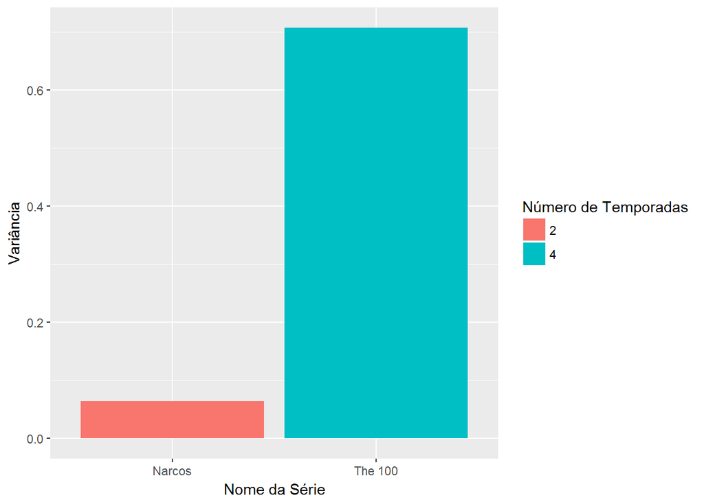

```r
# criando um data frame para as variancias

variancia <-group_by(dados, series_name) %>%
      summarise(SeriesVariance=var(rep(UserRating)), N_temporadas=max(season))

# Mostrando os dois extremos

serie <- c("The 100", "Narcos")
variancias <- c(max(variancia$SeriesVariance), min(variancia$SeriesVariance))
temporadas <- c(4, 2)

maxmin <- data.frame(serie, variancias, temporadas)

ggplot(maxmin, aes(serie, variancias, fill = as.factor(temporadas))) + labs(x = "Nome da Série", y = "Variância", fill = "Número de Temporadas") +
  geom_col()
```

```r
show(maxmin)
```

```
##     serie variancias temporadas
## 1 The 100 0.70717483          4
## 2  Narcos 0.06421053          2
```

Observamos que, the 100 realmente possui mais temporadas que Narcos, no entanto sabemos que existem séries com mais temporadas que the 100 e que possuem menor variância, pois há séries no conjunto de dados com mais de 4 temporadas. Portanto não podemos afirmar ainda se o número de temporadas realmente influencia na regularidade da qualidade dos episódios. Além disso, sabemos que houve uma queda enorme na avaliação dos episódios de the 100 por conta da morte de uma personagem na terceira temporada, que movimentou as redes sociais, pois sua morte contribuiu para uma “trope” muito usada no meio televisivo que é a de matar personagens que são LGBT. Portanto temos que com a movimentação nas redes sociais muitas pessoas avaliaram mal a terceira temporada de the 100 em forma de protesto, assim podemos descartar a série, a considerando um outlier por conta desse boicote.

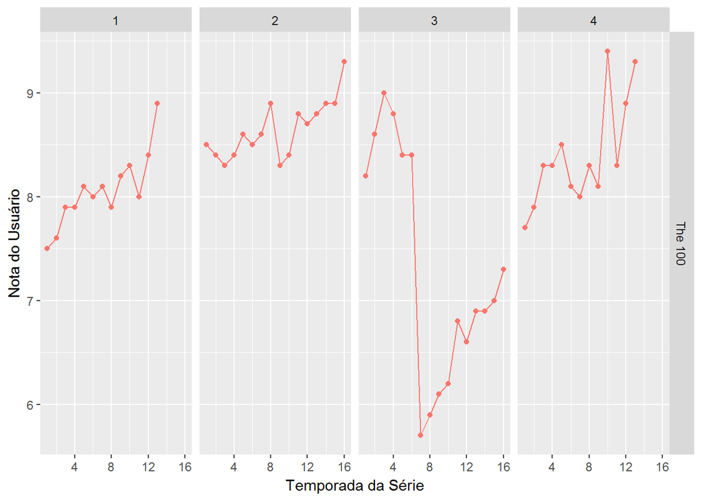

```r
t100 <- dados %>% filter(series_name %in% c("The 100"))

t100 %>%
  ggplot(aes(x = season_ep,y = UserRating, color="red")) + geom_line() + geom_point()+ facet_grid(series_name~season)+ labs(x= "Temporada da Série", y= "Nota do Usuário") + guides(color=FALSE)
```

O gráfico acima ilustra a queda brusca nas avaliações dos episódios de the 100. Assim usaremos a segunda série com maior variância para comparar com Narcos, que é The Simpsons, ela possui 0.54 de variância e tem 28 temporadas.

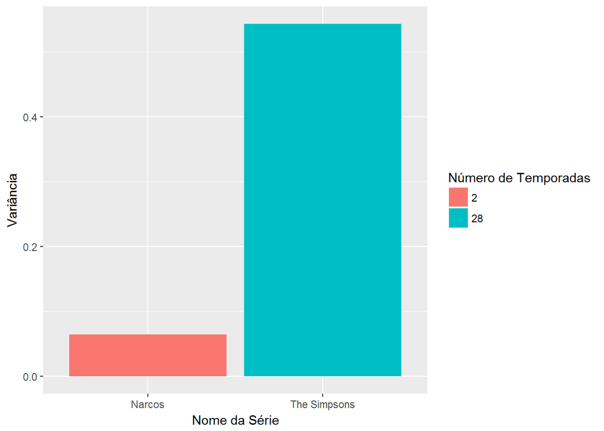

```r
# Mostrando os dois extremos

serie <- c("The Simpsons", "Narcos")
variancias <- c(0.5427355, min(variancia$SeriesVariance))
temporadas <- c(28, 2)

maxmin <- data.frame(serie, variancias, temporadas)

ggplot(maxmin, aes(serie, variancias, fill = as.factor(temporadas))) +
  geom_col() + labs(x = "Nome da Série", y = "Variância", fill = "Número de Temporadas")
```

```r
show(maxmin)
```

```
##          serie variancias temporadas
## 1 The Simpsons 0.54273550         28
## 2       Narcos 0.06421053          2
```

Apesar da diferença gritante entre o número de temporadas ainda assim não podemos afirmar com certeza que esse fator influencia diretamente a regularidade da qualidade dos episódios, pois estamos apenas olhando os extremos. Tendo isso em mente dividimos o conjunto de dados entre as 16 séries com maior variância e as 16 com menor variância e observamos seu número de temporadas.

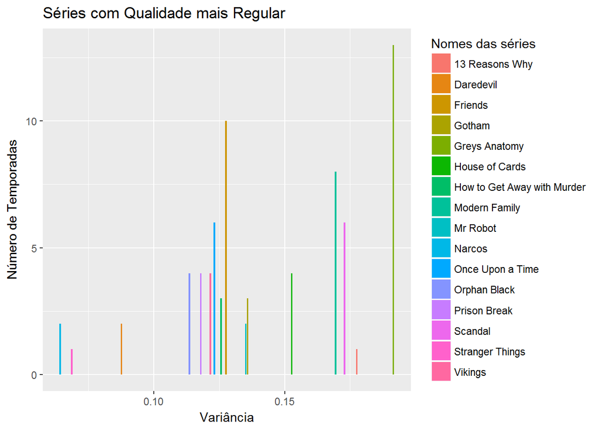

```r
mediana_variancia <- median(variancia$SeriesVariance)

var1 <- variancia %>% filter(SeriesVariance >= mediana_variancia)


var2 <- variancia %>% filter(SeriesVariance < mediana_variancia)



ggplot(var2, aes(SeriesVariance, N_temporadas, fill = series_name)) + labs(y= "Número de Temporadas", x= "Variância", title = "Séries com Qualidade mais Regular", fill = "Nomes das séries") +
  geom_col()
```

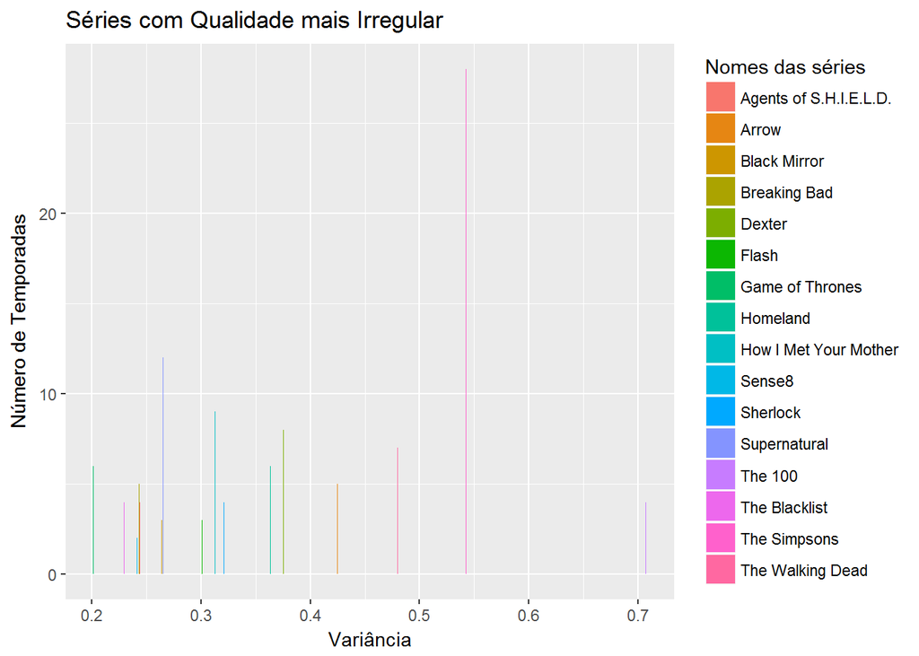

```r
ggplot(var1, aes(SeriesVariance, N_temporadas, fill = series_name)) + labs(y= "Número de Temporadas", x= "Variância", title =  "Séries com Qualidade mais Irregular", fill = "Nomes das séries") +
  geom_col()
```

Pelos gráficos podemos observar que 5 séries (31.25%) das séries com a variância mais baixa possuem um número de temporadas igual ou maior que 5, enquanto isso, dentre as séries com maior variância temos que 9 (56.25%) possuem 5 ou mais temporadas, ao retirar The 100, que foi considerado um outlier, a porcentagem de séries com maior variância e que possuem 5 ou mais temporadas sobe para 60%.

Abaixo será mostrado o gráfico das séries com maior variância sem The 100. Além disso observaremos a mediana de temporadas das 16 séries com qualidade mais regular e das 15 séries (pois the 100 foi removida) com qualidade mais irregular.

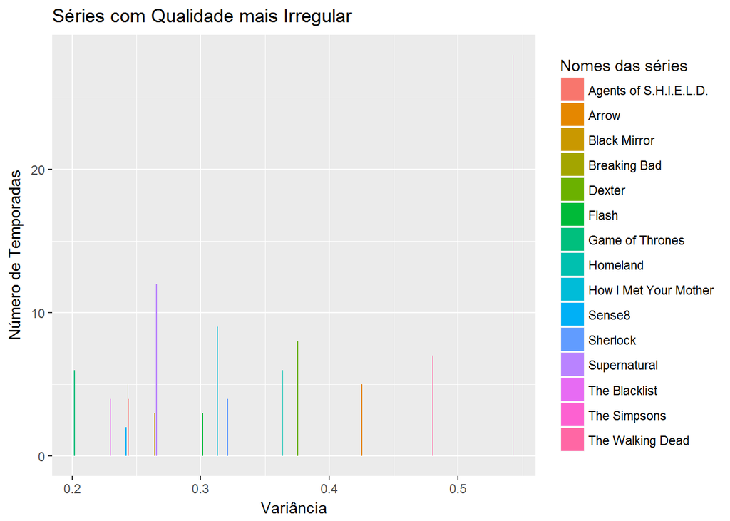

```r
var1 <- var1 %>% filter(series_name != "The 100")

ggplot(var1, aes(SeriesVariance, N_temporadas, fill = series_name)) + labs(y= "Número de Temporadas", x= "Variância", title =  "Séries com Qualidade mais Irregular", fill = "Nomes das séries") +
  geom_col()
```

```r
mediana_temporadas_regular <- median(var2$N_temporadas)
mediana_temporadas_irregular <- median(var1$N_temporadas)

#Qualidade mais regular
show(mediana_temporadas_regular)
```

```
## [1] 4
```

```r
#Qualidade menos regular
show(mediana_temporadas_irregular)
```

```
## [1] 5
```

Avaliando os gráficos notamos que não há um real crescimento quando se observa o número de temporadas em relação a variância, juntando isso com a observação da mediana de temporadas entre as 16 séries com menor irregularidade de qualidade de episódios (4) e as 15 com maior irregularidade (5) podemos concluir que o número de temporadas tem pouca influência sob a regularidade da qualidade dos episódios, não podemos afirmar com certeza que séries com muitas temporadas tem uma tendência forte a serem mais irregulares, portanto a hipótese inicial foi descartada.

### 1.1 - A série com qualidade mais regular é a mais bem avaliada?

Temos que Narcos é a série com qualidade mais regular dentre as que estão no conjunto de dados, queremos descobrir se ela é a mais bem avaliada, para isso analisaremos o valor da mediana das notas de cada série. Pois a mediana é o valor que separa a metade maior e a metade menor da amostra, portanto, uma série com mediana maior que 8, por exemplo, terá 50% dos seus episódios com notas maiores do que 8, enquanto uma série com mediana 7 terá 50% dos episódios com notas maiores que 7. Desse modo temos que a série de mediana 8 seria mais bem avaliada do que uma com mediana com o valor 7.

Além disso, a mediana foi escolhida por não ser tão distorcida por valores extremamente altos ou baixos, se fosse escolhida a média para descobrir a maior avaliação do IMDB nessa amostra uma série que possui 10 episódios apenas e um deles com uma nota muito baixa, digamos 2, estaria em desvantagem ao ser comparada a uma série com 100 episódios com apenas um deles tendo nota 2 também, porque a média da primeira série seria distorcida pelo valor baixo. Enquanto isso a mediana nos informa que 50% dos episódios possuem nota acima de x, portanto é mais justa quando avaliamos seriados com números de episódios diferentes.

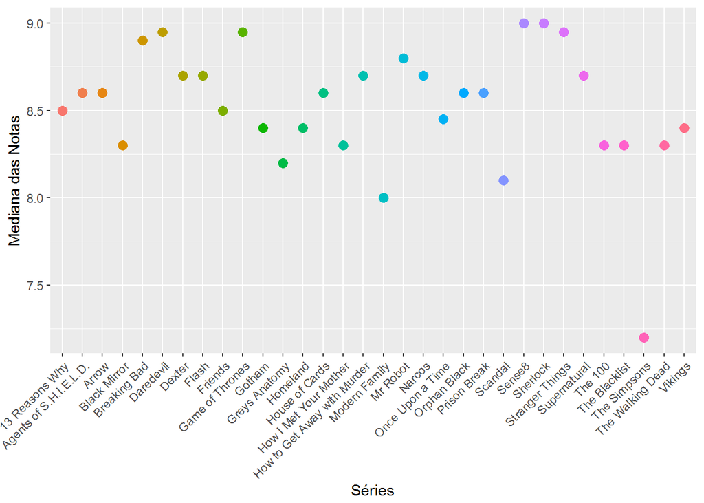

```r
# calculando as medianas e criando data frame para elas

notas_mediana <-group_by(dados, series_name) %>%
      summarise(notaMediana= median(rep(UserRating)))


notas_mediana %>% ggplot(aes(x=series_name , y= notaMediana, color = series_name)) + geom_point(size = 3) + theme(axis.text.x = element_text(angle = 45, hjust = 1)) + guides(color=FALSE) + labs(y = "Mediana das Notas", x = "Séries")
```

O gráfico acima mostra as medianas das notas de todas as séries do conjunto de dados, podemos observar que Sense8 e Sherlock ocupam o primeiro lugar tendo 9 como sua mediana de avaliação. Enquanto isso Narcos, a série com qualidade mais regular ocupa o décimo primeiro lugar no ranking de maior avaliação. Portanto ser a série com qualidade mais regular não implica que Narcos é a série mais bem avaliada.

```r
notas_mediana <- notas_mediana[order(notas_mediana$notaMediana, decreasing=TRUE),]

head(notas_mediana, n=12)
```

```
## # A tibble: 12 × 2
##                    series_name notaMediana
##                         <fctr>       <dbl>
## 1                       Sense8        9.00
## 2                     Sherlock        9.00
## 3                    Daredevil        8.95
## 4              Game of Thrones        8.95
## 5              Stranger Things        8.95
## 6                 Breaking Bad        8.90
## 7                     Mr Robot        8.80
## 8                       Dexter        8.70
## 9                        Flash        8.70
## 10 How to Get Away with Murder        8.70
## 11                      Narcos        8.70
## 12                Supernatural        8.70
```

### 2- Qual a série com a pior avaliação no IMDB?

Ainda observando o mesmo gráfico podemos verificar que a menor nota pertence a The Simpsons, sendo esta 7.2. Abaixo também será mostrado o gráfico das séries com as 5 piores notas.

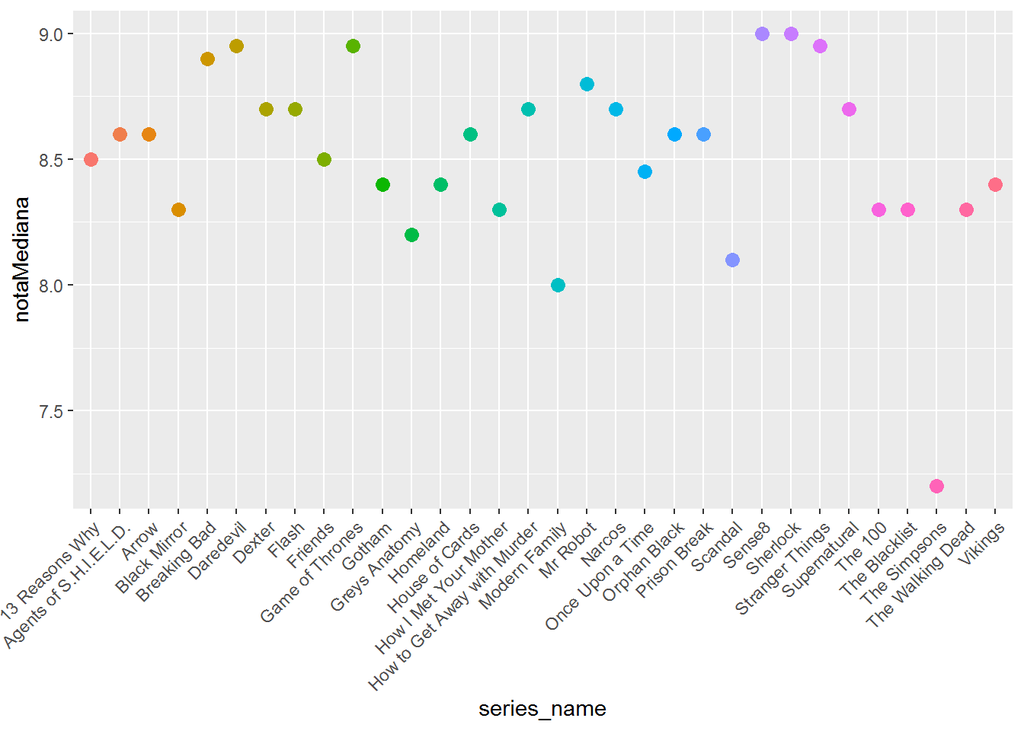

```r
notas_mediana %>% ggplot(aes(x=series_name , y= notaMediana, color = series_name)) + geom_point(size = 3) + theme(axis.text.x = element_text(angle = 45, hjust = 1)) + guides(color=FALSE)
```

```r
notas_mediana <- notas_mediana[order(notas_mediana$notaMediana),]

head(notas_mediana, n=5)
```

```
## # A tibble: 5 × 2
##     series_name notaMediana
##          <fctr>       <dbl>
## 1  The Simpsons         7.2
## 2 Modern Family         8.0
## 3       Scandal         8.1
## 4 Greys Anatomy         8.2
## 5  Black Mirror         8.3
```

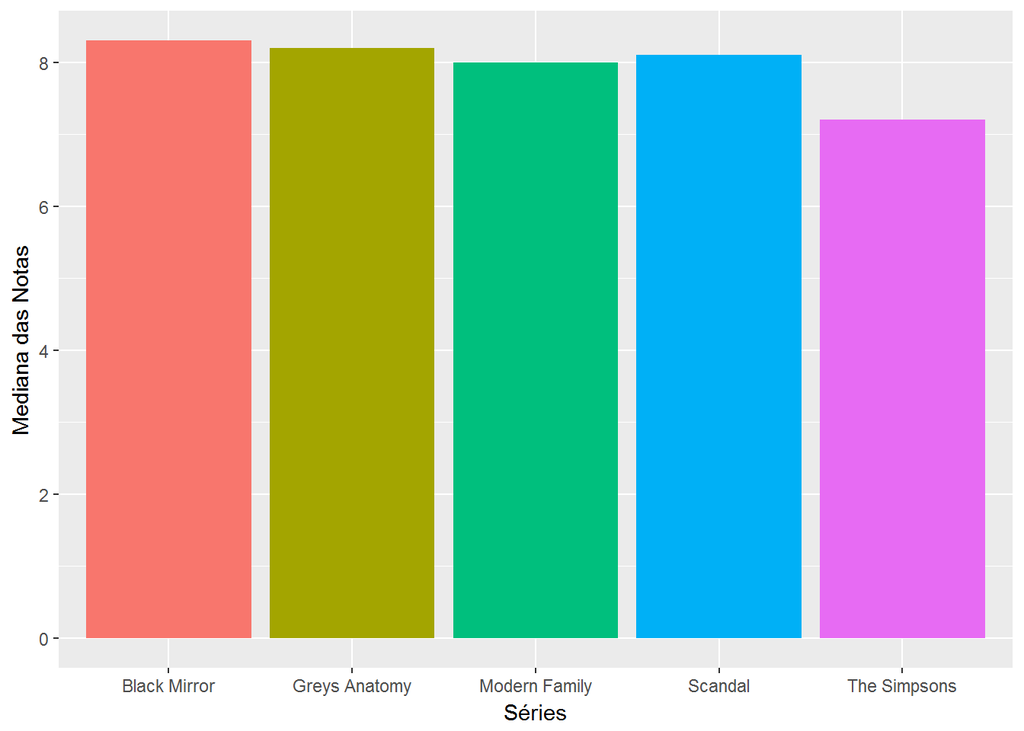

```r
worst5 <- notas_mediana %>% filter(series_name %in% c("The Simpsons", "Modern Family", "Scandal", "Greys Anatomy", "Black Mirror"))

worst5 %>% ggplot(aes(x= series_name , y = notaMediana, fill = series_name)) + geom_col(size = 3) + guides(fill=FALSE) + labs(y = "Mediana das Notas", x = "Séries")
```

### 2.1- O episódio pior avaliado pertence a série pior avaliada?

Abaixo visualizaremos o ranking dos 10 piores episódios avaliados pelo IMDB:

```r
dados1 <- dados[order(dados$UserRating),]
dados1 <- dados1[ -c(2:4, 7:18) ]

head(dados1, n=10)
```

```
##                series_name                  Episode UserRating
## 2655          The Simpsons           Lisa Goes Gaga        4.4
## 289                 Dexter   Remember the Monsters?        4.8
## 2336          The Simpsons All Singing, All Dancing        5.1
## 768          Greys Anatomy       How to Save a Life        5.2
## 441                  Arrow                   Schism        5.6
## 1915              Homeland         Long Time Coming        5.6
## 2433          The Simpsons               Gump Roast        5.6
## 855                The 100                 Thirteen        5.7
## 2147 How I Met Your Mother   Last Forever: Part Two        5.7
## 3059      The Walking Dead                    Swear        5.7
```

```r
dados1 <- dados1 %>% filter(UserRating <= 5.7)
```

Podemos observar que o pior episódio “Lisa Goes Gaga” é o da pior série avaliada, The Simpsons, portanto a hipótese levantada estava correta. Abaixo visualizaremos a distribuição de notas dos 10 episódios pior avaliados.

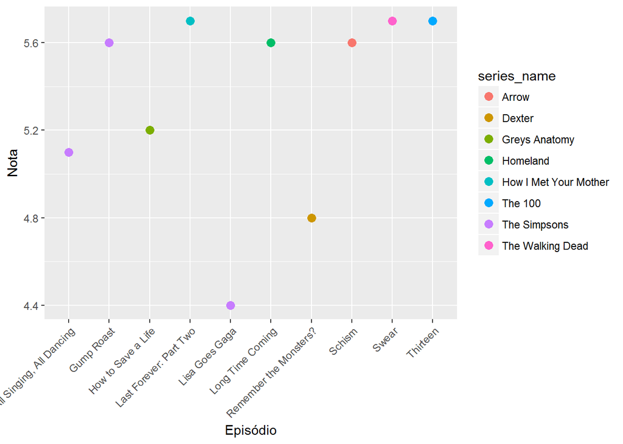

```r
dados1 %>% ggplot(aes(x= Episode , y = UserRating, color = series_name)) + geom_point(size = 3) + theme(axis.text.x = element_text(angle = 45, hjust = 1)) + labs(y = "Nota", x = "Episódio", fill = "Séries" )
```

Apesar do pior episódio ser de The Simpsons (e essa série ter mais 2 episódios entre os 10 piores avaliados) podemos observar que somente uma das outras séries que apareceram como pior avaliadas está presente no nosso último gráfico, sendo esta Grey’s Anatomy. Ao visualizar o boxplot dessas séries podemos ver que apenas Grey’s Anatomy e The Simpsons possuem episódios com notas igual ou abaixo de 5.2. No entanto ainda confirmamos nossa hipótese de que a série com pior avaliação teria também o pior episódio avaliado.

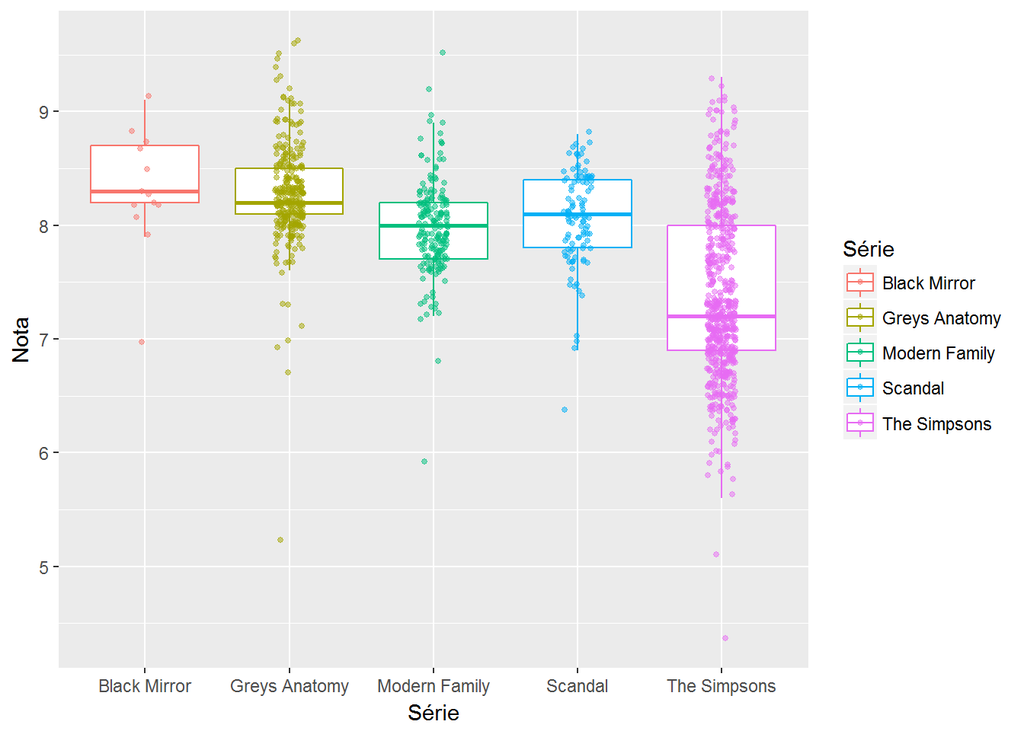

```r
worst5 <- dados %>% filter(series_name %in% c("The Simpsons", "Modern Family", "Scandal", "Greys Anatomy", "Black Mirror"))

worst5 %>%
  ggplot(aes(x = series_name,y = UserRating, color = series_name)) + geom_boxplot(outlier.color = NA) + labs( x= "Série", y= "Nota", color = "Série") + geom_jitter(width = .1, size = 1, alpha = .5)
```